# Risk Factor Analysis

## Outcome Variable

**Outcome Variable:** pers_wasted624

## Predictor Variables

**Intervention Variable:** ever_swasted06

**Adjustment Set:**

unadjusted

## Stratifying Variables

The analysis was stratified on these variable(s):

- studyid
- country

## Data Summary

| studyid | country | ever_swasted06 | pers_wasted624 | n_cell | n |
| --- | --- | --- | --- | --- | --- |
| ki0047075b-MAL-ED | BANGLADESH | 0 | 0 | 210 | 240 |
| ki0047075b-MAL-ED | BANGLADESH | 0 | 1 | 14 | 240 |
| ki0047075b-MAL-ED | BANGLADESH | 1 | 0 | 12 | 240 |
| ki0047075b-MAL-ED | BANGLADESH | 1 | 1 | 4 | 240 |
| ki0047075b-MAL-ED | BRAZIL | 0 | 0 | 198 | 202 |
| ki0047075b-MAL-ED | BRAZIL | 0 | 1 | 2 | 202 |
| ki0047075b-MAL-ED | BRAZIL | 1 | 0 | 2 | 202 |
| ki0047075b-MAL-ED | BRAZIL | 1 | 1 | 0 | 202 |
| ki0047075b-MAL-ED | INDIA | 0 | 0 | 197 | 234 |
| ki0047075b-MAL-ED | INDIA | 0 | 1 | 18 | 234 |
| ki0047075b-MAL-ED | INDIA | 1 | 0 | 9 | 234 |
| ki0047075b-MAL-ED | INDIA | 1 | 1 | 10 | 234 |
| ki0047075b-MAL-ED | NEPAL | 0 | 0 | 226 | 234 |
| ki0047075b-MAL-ED | NEPAL | 0 | 1 | 1 | 234 |
| ki0047075b-MAL-ED | NEPAL | 1 | 0 | 6 | 234 |
| ki0047075b-MAL-ED | NEPAL | 1 | 1 | 1 | 234 |
| ki0047075b-MAL-ED | PERU | 0 | 0 | 261 | 264 |
| ki0047075b-MAL-ED | PERU | 0 | 1 | 2 | 264 |
| ki0047075b-MAL-ED | PERU | 1 | 0 | 1 | 264 |
| ki0047075b-MAL-ED | PERU | 1 | 1 | 0 | 264 |
| ki0047075b-MAL-ED | SOUTH AFRICA | 0 | 0 | 252 | 258 |
| ki0047075b-MAL-ED | SOUTH AFRICA | 0 | 1 | 2 | 258 |
| ki0047075b-MAL-ED | SOUTH AFRICA | 1 | 0 | 4 | 258 |
| ki0047075b-MAL-ED | SOUTH AFRICA | 1 | 1 | 0 | 258 |
| ki0047075b-MAL-ED | TANZANIA, UNITED REPUBLIC OF | 0 | 0 | 241 | 244 |
| ki0047075b-MAL-ED | TANZANIA, UNITED REPUBLIC OF | 0 | 1 | 0 | 244 |
| ki0047075b-MAL-ED | TANZANIA, UNITED REPUBLIC OF | 1 | 0 | 3 | 244 |
| ki0047075b-MAL-ED | TANZANIA, UNITED REPUBLIC OF | 1 | 1 | 0 | 244 |
| ki1000107-Serrinha-VitA | BRAZIL | 0 | 0 | 10 | 11 |
| ki1000107-Serrinha-VitA | BRAZIL | 0 | 1 | 1 | 11 |

[output cut: 126 more lines]

The following strata were considered:

- studyid: ki0047075b-MAL-ED, country: BANGLADESH
- studyid: ki0047075b-MAL-ED, country: BRAZIL
- studyid: ki0047075b-MAL-ED, country: INDIA
- studyid: ki0047075b-MAL-ED, country: NEPAL
- studyid: ki0047075b-MAL-ED, country: PERU
- studyid: ki0047075b-MAL-ED, country: SOUTH AFRICA
- studyid: ki0047075b-MAL-ED, country: TANZANIA, UNITED REPUBLIC OF
- studyid: ki1000107-Serrinha-VitA, country: BRAZIL
- studyid: ki1000108-CMC-V-BCS-2002, country: INDIA
- studyid: ki1000108-IRC, country: INDIA
- studyid: ki1000109-EE, country: PAKISTAN
- studyid: ki1000109-ResPak, country: PAKISTAN
- studyid: ki1000304-VITAMIN-A, country: INDIA
- studyid: ki1000304b-SAS-CompFeed, country: INDIA
- studyid: ki1000304b-SAS-FoodSuppl, country: INDIA
- studyid: ki1017093-NIH-Birth, country: BANGLADESH
- studyid: ki1017093b-PROVIDE, country: BANGLADESH
- studyid: ki1017093c-NIH-Crypto, country: BANGLADESH
- studyid: ki1033518-iLiNS-DYAD-G, country: GHANA
- studyid: ki1066203-TanzaniaChild2, country: TANZANIA, UNITED REPUBLIC OF
- studyid: ki1101329-Keneba, country: GAMBIA
- studyid: ki1112895-Burkina Faso Zn, country: BURKINA FASO
- studyid: ki1112895-Guatemala BSC, country: GUATEMALA
- studyid: ki1113344-GMS-Nepal, country: NEPAL
- studyid: ki1114097-CMIN, country: BANGLADESH
- studyid: ki1114097-CMIN, country: BRAZIL
- studyid: ki1114097-CMIN, country: GUINEA-BISSAU
- studyid: ki1114097-CMIN, country: PERU
- studyid: ki1114097-CONTENT, country: PERU
- studyid: ki1119695-PROBIT, country: BELARUS
- studyid: ki1126311-ZVITAMBO, country: ZIMBABWE
- studyid: ki1135781-COHORTS, country: GUATEMALA
- studyid: ki1135781-COHORTS, country: INDIA
- studyid: ki1135781-COHORTS, country: PHILIPPINES
- studyid: ki1148112-iLiNS-DOSE, country: MALAWI
- studyid: ki1148112-iLiNS-DYAD-M, country: MALAWI
- studyid: ki1148112-LCNI-5, country: MALAWI
- studyid: kiGH5241-JiVitA-3, country: BANGLADESH
- studyid: kiGH5241-JiVitA-4, country: BANGLADESH

### Dropped Strata

Some strata were dropped due to rare outcomes:

- studyid: ki0047075b-MAL-ED, country: BANGLADESH
- studyid: ki0047075b-MAL-ED, country: BRAZIL
- studyid: ki0047075b-MAL-ED, country: NEPAL
- studyid: ki0047075b-MAL-ED, country: PERU
- studyid: ki0047075b-MAL-ED, country: SOUTH AFRICA
- studyid: ki0047075b-MAL-ED, country: TANZANIA, UNITED REPUBLIC OF
- studyid: ki1000107-Serrinha-VitA, country: BRAZIL
- studyid: ki1033518-iLiNS-DYAD-G, country: GHANA
- studyid: ki1112895-Burkina Faso Zn, country: BURKINA FASO
- studyid: ki1112895-Guatemala BSC, country: GUATEMALA
- studyid: ki1114097-CMIN, country: BRAZIL
- studyid: ki1114097-CMIN, country: GUINEA-BISSAU
- studyid: ki1114097-CMIN, country: PERU
- studyid: ki1114097-CONTENT, country: PERU
- studyid: ki1135781-COHORTS, country: GUATEMALA
- studyid: ki1148112-iLiNS-DOSE, country: MALAWI
- studyid: ki1148112-iLiNS-DYAD-M, country: MALAWI
- studyid: ki1148112-LCNI-5, country: MALAWI

## Methods Detail

We’re interested in the causal parameters $E[Y_a]$ for all values of $a \in \mathcal{A}$. These parameters represent the mean outcome if, possibly contrary to fact, we intervened to set all units to have $A=a$. Under the randomization and positivity assumptions, these are identified by the statistical parameters $\psi_a=E_W[E_{Y|A,W}(Y|A=a,W)]$. In addition, we’re interested in the mean of $Y$, $E[Y]$ under no intervention (the observed mean). We will estimate these parameters by using SuperLearner to fit the relevant likelihood factors – $E_{Y|A,W}(Y|A=a,W)$ and $p(A=a|W)$, and then updating our likelihood fit using a joint TMLE.

For unadjusted analyses ($W=\{\}$), initial likelihoods were estimated using Lrnr_glm to estimate the simple $E(Y|A)$ and Lrnr_mean to estimate $p(A)$. For adjusted analyses, a small library containing Lrnr_glmnet, Lrnr_xgboost, and Lrnr_mean was used.

Having estimated these parameters, we will then use the delta method to estimate relative risks and attributable risks relative to a prespecified baseline level of $A$.

# Results Detail

## Results Plots

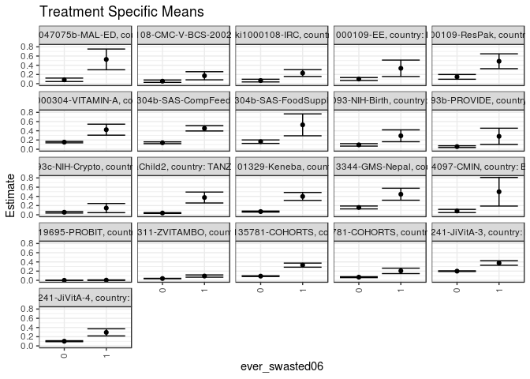

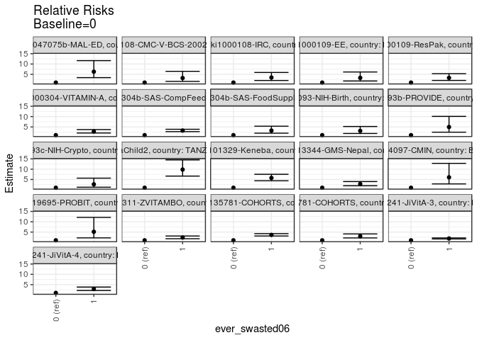

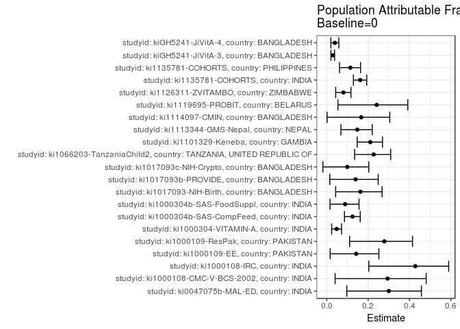

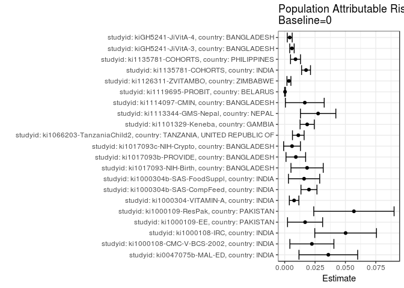

## Results Table

### Parameter: TSM

| studyid | country | intervention_level | baseline_level | estimate | ci_lower | ci_upper |
| --- | --- | --- | --- | --- | --- | --- |
| ki0047075b-MAL-ED | INDIA | 0 | NA | 0.0837209 | 0.0466196 | 0.1208223 |
| ki0047075b-MAL-ED | INDIA | 1 | NA | 0.5263158 | 0.3013228 | 0.7513087 |
| ki1000108-CMC-V-BCS-2002 | INDIA | 0 | NA | 0.0536913 | 0.0280642 | 0.0793184 |
| ki1000108-CMC-V-BCS-2002 | INDIA | 1 | NA | 0.1714286 | 0.0830196 | 0.2598376 |
| ki1000108-IRC | INDIA | 0 | NA | 0.0669014 | 0.0378076 | 0.0959952 |
| ki1000108-IRC | INDIA | 1 | NA | 0.2301587 | 0.1565707 | 0.3037468 |
| ki1000109-EE | PAKISTAN | 0 | NA | 0.1011561 | 0.0693411 | 0.1329710 |
| ki1000109-EE | PAKISTAN | 1 | NA | 0.3333333 | 0.1552830 | 0.5113837 |
| ki1000109-ResPak | PAKISTAN | 0 | NA | 0.1475410 | 0.0960413 | 0.1990407 |
| ki1000109-ResPak | PAKISTAN | 1 | NA | 0.4864865 | 0.3250700 | 0.6479030 |
| ki1000304-VITAMIN-A | INDIA | 0 | NA | 0.1539839 | 0.1390137 | 0.1689541 |
| ki1000304-VITAMIN-A | INDIA | 1 | NA | 0.4242424 | 0.3049817 | 0.5435031 |
| ki1000304b-SAS-CompFeed | INDIA | 0 | NA | 0.1403648 | 0.1209577 | 0.1597719 |
| ki1000304b-SAS-CompFeed | INDIA | 1 | NA | 0.4534884 | 0.3963909 | 0.5105859 |
| ki1000304b-SAS-FoodSuppl | INDIA | 0 | NA | 0.1639785 | 0.1263048 | 0.2016521 |
| ki1000304b-SAS-FoodSuppl | INDIA | 1 | NA | 0.5294118 | 0.2918372 | 0.7669863 |
| ki1017093-NIH-Birth | BANGLADESH | 0 | NA | 0.0948276 | 0.0681439 | 0.1215113 |
| ki1017093-NIH-Birth | BANGLADESH | 1 | NA | 0.2916667 | 0.1629561 | 0.4203772 |
| ki1017093b-PROVIDE | BANGLADESH | 0 | NA | 0.0565068 | 0.0377647 | 0.0752490 |
| ki1017093b-PROVIDE | BANGLADESH | 1 | NA | 0.2800000 | 0.1038510 | 0.4561490 |
| ki1017093c-NIH-Crypto | BANGLADESH | 0 | NA | 0.0548961 | 0.0376882 | 0.0721041 |
| ki1017093c-NIH-Crypto | BANGLADESH | 1 | NA | 0.1458333 | 0.0459189 | 0.2457477 |
| ki1066203-TanzaniaChild2 | TANZANIA, UNITED REPUBLIC OF | 0 | NA | 0.0382131 | 0.0294938 | 0.0469325 |
| ki1066203-TanzaniaChild2 | TANZANIA, UNITED REPUBLIC OF | 1 | NA | 0.3750000 | 0.2563612 | 0.4936388 |
| ki1101329-Keneba | GAMBIA | 0 | NA | 0.0693838 | 0.0584109 | 0.0803567 |
| ki1101329-Keneba | GAMBIA | 1 | NA | 0.3983740 | 0.3118366 | 0.4849114 |
| ki1113344-GMS-Nepal | NEPAL | 0 | NA | 0.1590909 | 0.1278661 | 0.1903158 |
| ki1113344-GMS-Nepal | NEPAL | 1 | NA | 0.4464286 | 0.3161152 | 0.5767420 |
| ki1114097-CMIN | BANGLADESH | 0 | NA | 0.0826446 | 0.0478846 | 0.1174046 |
| ki1114097-CMIN | BANGLADESH | 1 | NA | 0.5000000 | 0.1894858 | 0.8105142 |
| ki1119695-PROBIT | BELARUS | 0 | NA | 0.0009220 | 0.0001900 | 0.0016540 |
| ki1119695-PROBIT | BELARUS | 1 | NA | 0.0047431 | -0.0002339 | 0.0097201 |
| ki1126311-ZVITAMBO | ZIMBABWE | 0 | NA | 0.0398241 | 0.0355281 | 0.0441201 |
| ki1126311-ZVITAMBO | ZIMBABWE | 1 | NA | 0.0933573 | 0.0691950 | 0.1175196 |
| ki1135781-COHORTS | INDIA | 0 | NA | 0.0911759 | 0.0835336 | 0.0988183 |
| ki1135781-COHORTS | INDIA | 1 | NA | 0.3302540 | 0.2859524 | 0.3745557 |
| ki1135781-COHORTS | PHILIPPINES | 0 | NA | 0.0690994 | 0.0593035 | 0.0788952 |
| ki1135781-COHORTS | PHILIPPINES | 1 | NA | 0.2055556 | 0.1465100 | 0.2646011 |
| kiGH5241-JiVitA-3 | BANGLADESH | 0 | NA | 0.1999709 | 0.1924520 | 0.2074898 |
| kiGH5241-JiVitA-3 | BANGLADESH | 1 | NA | 0.3760331 | 0.3273998 | 0.4246663 |
| kiGH5241-JiVitA-4 | BANGLADESH | 0 | NA | 0.1017087 | 0.0909066 | 0.1125109 |
| kiGH5241-JiVitA-4 | BANGLADESH | 1 | NA | 0.2935780 | 0.2161239 | 0.3710320 |

### Parameter: E(Y)

| studyid | country | intervention_level | baseline_level | estimate | ci_lower | ci_upper |
| --- | --- | --- | --- | --- | --- | --- |
| ki0047075b-MAL-ED | INDIA | NA | NA | 0.1196581 | 0.0779840 | 0.1613323 |
| ki1000108-CMC-V-BCS-2002 | INDIA | NA | NA | 0.0760870 | 0.0489610 | 0.1032130 |
| ki1000108-IRC | INDIA | NA | NA | 0.1170732 | 0.0859146 | 0.1482317 |
| ki1000109-EE | PAKISTAN | NA | NA | 0.1179625 | 0.0851837 | 0.1507412 |
| ki1000109-ResPak | PAKISTAN | NA | NA | 0.2045455 | 0.1511224 | 0.2579685 |
| ki1000304-VITAMIN-A | INDIA | NA | NA | 0.1617391 | 0.1466878 | 0.1767905 |
| ki1000304b-SAS-CompFeed | INDIA | NA | NA | 0.1603563 | 0.1395035 | 0.1812092 |
| ki1000304b-SAS-FoodSuppl | INDIA | NA | NA | 0.1799486 | 0.1417254 | 0.2181718 |
| ki1017093-NIH-Birth | BANGLADESH | NA | NA | 0.1132813 | 0.0858017 | 0.1407608 |
| ki1017093b-PROVIDE | BANGLADESH | NA | NA | 0.0656814 | 0.0459906 | 0.0853723 |
| ki1017093c-NIH-Crypto | BANGLADESH | NA | NA | 0.0609418 | 0.0434802 | 0.0784034 |
| ki1066203-TanzaniaChild2 | TANZANIA, UNITED REPUBLIC OF | NA | NA | 0.0494277 | 0.0397346 | 0.0591208 |
| ki1101329-Keneba | GAMBIA | NA | NA | 0.0879121 | 0.0760335 | 0.0997906 |
| ki1113344-GMS-Nepal | NEPAL | NA | NA | 0.1866438 | 0.1550166 | 0.2182711 |
| ki1114097-CMIN | BANGLADESH | NA | NA | 0.0992063 | 0.0622241 | 0.1361886 |
| ki1119695-PROBIT | BELARUS | NA | NA | 0.0012159 | 0.0002433 | 0.0021885 |
| ki1126311-ZVITAMBO | ZIMBABWE | NA | NA | 0.0433251 | 0.0390011 | 0.0476491 |
| ki1135781-COHORTS | INDIA | NA | NA | 0.1087695 | 0.1008135 | 0.1167256 |
| ki1135781-COHORTS | PHILIPPINES | NA | NA | 0.0780116 | 0.0679971 | 0.0880261 |
| kiGH5241-JiVitA-3 | BANGLADESH | NA | NA | 0.2059588 | 0.1983834 | 0.2135343 |
| kiGH5241-JiVitA-4 | BANGLADESH | NA | NA | 0.1058706 | 0.0951082 | 0.1166331 |

### Parameter: RR

| studyid | country | intervention_level | baseline_level | estimate | ci_lower | ci_upper |
| --- | --- | --- | --- | --- | --- | --- |
| ki0047075b-MAL-ED | INDIA | 0 | 0 | 1.000000 | 1.000000 | 1.000000 |
| ki0047075b-MAL-ED | INDIA | 1 | 0 | 6.286550 | 3.396264 | 11.636523 |
| ki1000108-CMC-V-BCS-2002 | INDIA | 0 | 0 | 1.000000 | 1.000000 | 1.000000 |
| ki1000108-CMC-V-BCS-2002 | INDIA | 1 | 0 | 3.192857 | 1.581252 | 6.447001 |
| ki1000108-IRC | INDIA | 0 | 0 | 1.000000 | 1.000000 | 1.000000 |
| ki1000108-IRC | INDIA | 1 | 0 | 3.440267 | 2.005288 | 5.902116 |
| ki1000109-EE | PAKISTAN | 0 | 0 | 1.000000 | 1.000000 | 1.000000 |
| ki1000109-EE | PAKISTAN | 1 | 0 | 3.295238 | 1.772889 | 6.124801 |
| ki1000109-ResPak | PAKISTAN | 0 | 0 | 1.000000 | 1.000000 | 1.000000 |
| ki1000109-ResPak | PAKISTAN | 1 | 0 | 3.297297 | 2.037069 | 5.337163 |
| ki1000304-VITAMIN-A | INDIA | 0 | 0 | 1.000000 | 1.000000 | 1.000000 |
| ki1000304-VITAMIN-A | INDIA | 1 | 0 | 2.755109 | 2.046245 | 3.709540 |
| ki1000304b-SAS-CompFeed | INDIA | 0 | 0 | 1.000000 | 1.000000 | 1.000000 |
| ki1000304b-SAS-CompFeed | INDIA | 1 | 0 | 3.230784 | 2.706712 | 3.856327 |
| ki1000304b-SAS-FoodSuppl | INDIA | 0 | 0 | 1.000000 | 1.000000 | 1.000000 |
| ki1000304b-SAS-FoodSuppl | INDIA | 1 | 0 | 3.228544 | 1.950111 | 5.345078 |
| ki1017093-NIH-Birth | BANGLADESH | 0 | 0 | 1.000000 | 1.000000 | 1.000000 |
| ki1017093-NIH-Birth | BANGLADESH | 1 | 0 | 3.075758 | 1.822440 | 5.190999 |
| ki1017093b-PROVIDE | BANGLADESH | 0 | 0 | 1.000000 | 1.000000 | 1.000000 |
| ki1017093b-PROVIDE | BANGLADESH | 1 | 0 | 4.955152 | 2.433290 | 10.090670 |
| ki1017093c-NIH-Crypto | BANGLADESH | 0 | 0 | 1.000000 | 1.000000 | 1.000000 |
| ki1017093c-NIH-Crypto | BANGLADESH | 1 | 0 | 2.656531 | 1.250558 | 5.643210 |
| ki1066203-TanzaniaChild2 | TANZANIA, UNITED REPUBLIC OF | 0 | 0 | 1.000000 | 1.000000 | 1.000000 |
| ki1066203-TanzaniaChild2 | TANZANIA, UNITED REPUBLIC OF | 1 | 0 | 9.813380 | 6.643751 | 14.495190 |
| ki1101329-Keneba | GAMBIA | 0 | 0 | 1.000000 | 1.000000 | 1.000000 |
| ki1101329-Keneba | GAMBIA | 1 | 0 | 5.741600 | 4.388733 | 7.511501 |
| ki1113344-GMS-Nepal | NEPAL | 0 | 0 | 1.000000 | 1.000000 | 1.000000 |
| ki1113344-GMS-Nepal | NEPAL | 1 | 0 | 2.806122 | 1.973981 | 3.989057 |
| ki1114097-CMIN | BANGLADESH | 0 | 0 | 1.000000 | 1.000000 | 1.000000 |
| ki1114097-CMIN | BANGLADESH | 1 | 0 | 6.050000 | 2.857670 | 12.808512 |
| ki1119695-PROBIT | BELARUS | 0 | 0 | 1.000000 | 1.000000 | 1.000000 |
| ki1119695-PROBIT | BELARUS | 1 | 0 | 5.144212 | 2.183254 | 12.120863 |
| ki1126311-ZVITAMBO | ZIMBABWE | 0 | 0 | 1.000000 | 1.000000 | 1.000000 |
| ki1126311-ZVITAMBO | ZIMBABWE | 1 | 0 | 2.344239 | 1.771035 | 3.102964 |
| ki1135781-COHORTS | INDIA | 0 | 0 | 1.000000 | 1.000000 | 1.000000 |
| ki1135781-COHORTS | INDIA | 1 | 0 | 3.622162 | 3.092231 | 4.242912 |
| ki1135781-COHORTS | PHILIPPINES | 0 | 0 | 1.000000 | 1.000000 | 1.000000 |
| ki1135781-COHORTS | PHILIPPINES | 1 | 0 | 2.974782 | 2.159430 | 4.097992 |
| kiGH5241-JiVitA-3 | BANGLADESH | 0 | 0 | 1.000000 | 1.000000 | 1.000000 |
| kiGH5241-JiVitA-3 | BANGLADESH | 1 | 0 | 1.880439 | 1.646151 | 2.148072 |
| kiGH5241-JiVitA-4 | BANGLADESH | 0 | 0 | 1.000000 | 1.000000 | 1.000000 |
| kiGH5241-JiVitA-4 | BANGLADESH | 1 | 0 | 2.886459 | 2.177635 | 3.826006 |

### Parameter: PAR

| studyid | country | intervention_level | baseline_level | estimate | ci_lower | ci_upper |
| --- | --- | --- | --- | --- | --- | --- |
| ki0047075b-MAL-ED | INDIA | 0 | NA | 0.0359372 | 0.0117760 | 0.0600983 |
| ki1000108-CMC-V-BCS-2002 | INDIA | 0 | NA | 0.0223957 | 0.0042595 | 0.0405319 |
| ki1000108-IRC | INDIA | 0 | NA | 0.0501718 | 0.0247815 | 0.0755620 |
| ki1000109-EE | PAKISTAN | 0 | NA | 0.0168064 | 0.0023568 | 0.0312560 |
| ki1000109-ResPak | PAKISTAN | 0 | NA | 0.0570045 | 0.0239301 | 0.0900788 |
| ki1000304-VITAMIN-A | INDIA | 0 | NA | 0.0077552 | 0.0038440 | 0.0116665 |
| ki1000304b-SAS-CompFeed | INDIA | 0 | NA | 0.0199916 | 0.0134133 | 0.0265699 |
| ki1000304b-SAS-FoodSuppl | INDIA | 0 | NA | 0.0159701 | 0.0030953 | 0.0288449 |
| ki1017093-NIH-Birth | BANGLADESH | 0 | NA | 0.0184537 | 0.0051643 | 0.0317431 |
| ki1017093b-PROVIDE | BANGLADESH | 0 | NA | 0.0091746 | 0.0010935 | 0.0172557 |
| ki1017093c-NIH-Crypto | BANGLADESH | 0 | NA | 0.0060457 | -0.0008945 | 0.0129859 |
| ki1066203-TanzaniaChild2 | TANZANIA, UNITED REPUBLIC OF | 0 | NA | 0.0112145 | 0.0064195 | 0.0160096 |
| ki1101329-Keneba | GAMBIA | 0 | NA | 0.0185283 | 0.0126753 | 0.0243812 |
| ki1113344-GMS-Nepal | NEPAL | 0 | NA | 0.0275529 | 0.0129833 | 0.0421226 |
| ki1114097-CMIN | BANGLADESH | 0 | NA | 0.0165617 | 0.0005829 | 0.0325406 |
| ki1119695-PROBIT | BELARUS | 0 | NA | 0.0002939 | -0.0000417 | 0.0006294 |
| ki1126311-ZVITAMBO | ZIMBABWE | 0 | NA | 0.0035010 | 0.0018716 | 0.0051304 |
| ki1135781-COHORTS | INDIA | 0 | NA | 0.0175936 | 0.0139208 | 0.0212664 |
| ki1135781-COHORTS | PHILIPPINES | 0 | NA | 0.0089122 | 0.0048054 | 0.0130191 |
| kiGH5241-JiVitA-3 | BANGLADESH | 0 | NA | 0.0059879 | 0.0041568 | 0.0078190 |
| kiGH5241-JiVitA-4 | BANGLADESH | 0 | NA | 0.0041619 | 0.0021337 | 0.0061902 |

### Parameter: PAF

| studyid | country | intervention_level | baseline_level | estimate | ci_lower | ci_upper |
| --- | --- | --- | --- | --- | --- | --- |
| ki0047075b-MAL-ED | INDIA | 0 | NA | 0.3003322 | 0.0968199 | 0.4579874 |
| ki1000108-CMC-V-BCS-2002 | INDIA | 0 | NA | 0.2943432 | 0.0402926 | 0.4811424 |
| ki1000108-IRC | INDIA | 0 | NA | 0.4285505 | 0.2035296 | 0.5899978 |
| ki1000109-EE | PAKISTAN | 0 | NA | 0.1424724 | 0.0165879 | 0.2522427 |
| ki1000109-ResPak | PAKISTAN | 0 | NA | 0.2786885 | 0.1106706 | 0.4149634 |
| ki1000304-VITAMIN-A | INDIA | 0 | NA | 0.0479491 | 0.0237253 | 0.0715718 |
| ki1000304b-SAS-CompFeed | INDIA | 0 | NA | 0.1246696 | 0.0856993 | 0.1619789 |
| ki1000304b-SAS-FoodSuppl | INDIA | 0 | NA | 0.0887481 | 0.0159449 | 0.1561650 |
| ki1017093-NIH-Birth | BANGLADESH | 0 | NA | 0.1629013 | 0.0431098 | 0.2676963 |
| ki1017093b-PROVIDE | BANGLADESH | 0 | NA | 0.1396832 | 0.0148104 | 0.2487284 |
| ki1017093c-NIH-Crypto | BANGLADESH | 0 | NA | 0.0992042 | -0.0185911 | 0.2033770 |
| ki1066203-TanzaniaChild2 | TANZANIA, UNITED REPUBLIC OF | 0 | NA | 0.2268880 | 0.1346658 | 0.3092817 |
| ki1101329-Keneba | GAMBIA | 0 | NA | 0.2107593 | 0.1471283 | 0.2696430 |
| ki1113344-GMS-Nepal | NEPAL | 0 | NA | 0.1476230 | 0.0685892 | 0.2199505 |
| ki1114097-CMIN | BANGLADESH | 0 | NA | 0.1669421 | 0.0014737 | 0.3049904 |
| ki1119695-PROBIT | BELARUS | 0 | NA | 0.2416820 | 0.0541509 | 0.3920318 |
| ki1126311-ZVITAMBO | ZIMBABWE | 0 | NA | 0.0808075 | 0.0432534 | 0.1168875 |
| ki1135781-COHORTS | INDIA | 0 | NA | 0.1617513 | 0.1290542 | 0.1932208 |
| ki1135781-COHORTS | PHILIPPINES | 0 | NA | 0.1142424 | 0.0618753 | 0.1636863 |
| kiGH5241-JiVitA-3 | BANGLADESH | 0 | NA | 0.0290734 | 0.0202411 | 0.0378260 |
| kiGH5241-JiVitA-4 | BANGLADESH | 0 | NA | 0.0393116 | 0.0198406 | 0.0583957 |